# 04-Dijkstra-Algorithm

## Dijkstra's Shortest-Path Algorithm

As the name implies, paths are routes from one vertex in a graph to another. They may be direct, in the sense that there is an edge from one vertex directly to another, or indirect, in the sense that they involve one or more intermediate vertices (think layovers for airline flights).

Similarly you may model a road network between cities as a graph, with vertices representing cities and edges representing roads. Each road may have a weight associated with it, corresponding to the distance or time it takes to travel that road. An extremely common problem is to find the shortest path between two locations in this network, such as when you use Google Maps to find the shortest route between two locations.

With weights on edges corresponding to distances or time, it is often desirable to determine the *shortest* path between two vertices. Dijkstra's shortest-paths algorithm allows us to determine this. This algorithm is named after its inventor, Edsger Dijkstra, a Dutch computer scientist, who devised it in 1956 and won the Turing Award in 1972 for his contributions to computer science.

### Priority Queues

Before we dive into the algorithm, we need to introduce a new data structure, the *priority queue*. A priority queue is a data structure that allows us to store a collection of elements, each of which has a *priority*. The priority queue supports two main operations:

- `enqueue(x, p)`: insert element `x` with priority `p`.
- `dequeue()`: remove the element with the highest (or lowest) priority.

Note that `p` is a number, and the lower the number, the higher the priority. Priority Queues can be constructed to support either min or max priority. In a *min priority queue*, the element with the lowest priority is removed first. In a *max priority queue*, the element with the highest priority is removed first.

If there are multiple elements with the same highest priority, then the priority queue may return any of them.

Note that a priority queue is not a *queue* in the sense of a FIFO data structure. Each element gets a priority and the next element to be serviced the the one with the highest priority (i.e. the lowest number).

We can implement a priority queue using a specialized tree structure called a **heap**. We will learn more about heaps later in the quarter.

### Intuition

We will, in fact, think about the airline flight network, where some cities are linked with direct flights while others are not. For cities with direct flights, there is a distance between them that any such flight must traverse. For example, consider the following graph, where vertices represent airports, and edges represent flights between airports (and the weight of the edge is the distance between the airports)

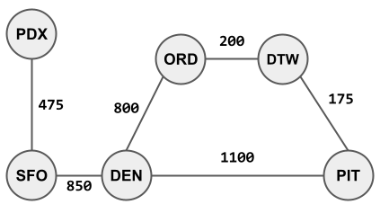

We wish to know the shortest path, possibly involving one or more layovers, between a pair of cities.

As humans, we could look at the graph and, using insight and, perhaps, some trial-and-error, divine the best route. But, an algorithm cannot see the gestalt of the graph. It must analyze the graph by moving around one hop at a time and use some systematic approach.

Here is how to conceptualize the way to go about this. I really, really want to know the fastest way to get from ORD to SFO, but there is no direct flight (at least according to our graph). I am going to fly this route a lot, and have the budget to spend a lot of money to figure it out. To do so, I hire a bunch of scouts and promise to buy them any tickets they want. They each start at ORD, but start taking different flights out of ORD to different destinations. Upon arriving at another airport, they take some other flight, and so on. There are enough scouts that they are exploring all possible itineraries.

Eventually, one scout will make it to SFO. As time goes on, we might expect that all scouts will make it there, one way or another. But, we are looking for the shortest path, so the scout that gets there first, in other words, "wins the race," is the one who has discovered the best way to get there. I ask the scouts to call me when they arrive at SFO. Upon receiving the first such call, I interrogate the scout on the route they took. When later scouts arrive at SFO, I let the calls go to voicemail.

(For this story to make sense, it must be possible to land at an intermediate airport and then immediately take a new flight to somewhere else with absolutely no layover.)

### Pseudocode

See the Dijkstra's Algorithm Example posted on Canvas for a detailed walkthrough of the algorithm.

The pseudocode for Dijkstra's algorithm is the following:

```
Input: Graph, start vertex, destination vertex

dist <- Table mapping vertices to tentative distances.

prev <- Table mapping vertices to other vertices
        (representing the previous vertex in the shortest path to that vertex)

PQ <- Empty priority queue

For every vertex in graph
    dist[vertex] <- infinity

dist[start vertex] = 0
Add (0, start vertex) to PQ

While PQ is not empty:
    cur <- Dequeue from PQ (i.e., extract minimum distance vertex)

    if cur is the destination vertex
        We are done (alternatively, keep going to fill out the
        entire distance table, and find the shortest path to
        every vertex in the graph)

    for every neighbor of cur:
        new_dist = dist[cur] + weight(cur, neighbor)

        if new_dist < dist[neighbor]:
            dist[neighbor] = new_dist
            prev[neighbor] = cur
            Update priority of neighbor in PQ with new_dist
              (or insert in PQ if not already there)
```

When using a priority queue, this algorithm will take $O((|E| + |V|)\cdot\log |V|)$ time. It is possible to implement Dijkstra's without a priority queue (using just a list of unprocessed vertices), but then the algorithm takes $O(|V|^2)$ time.

### Limitations and Other Algorithms

Dijkstra's Algorithm is a single-source algorithm, meaning it will find the shortest path starting at a specific source vertex. If we wanted to find the shortest path starting at other vertices, we would have to re-run the algorithm. Additionally, it will not work if any of the edges have negative weights.

Here are a few alternatives/enhancements to Dijkstra's Algorithm:

- **Bellman–Ford algorithm**: Allows for negative edges, as long as there are no negative cycles reachable from the source.
- **A★ Search**: Improves performance of Dijkstra by using heuristics to explore more promising paths first.
- **Floyd–Warshall algorithm**: Unlike Dijkstra's, Bellman-Ford, and A★ (which are all single-source), this is an *all-pairs* algorithm that will find the shortest path between each pair of nodes in the graph. It allows for negative edges, as long as there are no negative cycles reachable from the source.